# Assignment 2

Ria Sharma

### Aims

- Read ggplot2 code examples for making graphics and describe what different commands do;
- Practice using `ggplot2` commands on new data to mimic examples from lecture.

### Preliminaries

This file assumes that your course home directory has the following folders:

- `COURSE/data/`
- `COURSE/homework/`
- `COURSE/homework/hw02`

You must also have installed the **tidyverse** and **viridislLite** libraries.

Follow these steps:

- Download the file `lake-monona-winters-2023.csv` and place it in the `COURSE/data/` directory.
- Download the file `hw02.Rmd` and place into the `COURSE/homework/hw02/` directory.
- Navigate to the `COURSE/homework/hw02/` directory and set it to be your working directory.

### Data

##### Lake Monona

Data in *lake-monona-winters-2023.csv* is similar to that in the Lake Mendota data set from lecture, but contains freeze durations in Lake Monona, **and not from Lake Mendota**. There is one row from each winter from 1855–56 through 2022–23.

Variables in the data set are:

- winter — a string such as “1855-56” which specifies the winter
- year1 — the first year of the winter
- periods — the number of periods of consecutive days where the surface of Lake Monona was closed by 50% or more of ice.
- duration — the total number of days during the winter that 50% or more of the lake surface is frozen (closed by ice)
- first_freeze — the first date the lake is closed during the winter
- last_thaw — the date of the last thaw during the winter
- decade — the decade of the first winter
- period50 — a 50-year period of time
- ff_x — the number of days after June 30 of the first freeze
- ff_cat — a categorical variable of the half-month of the first freeze

*Note: lecture notes had a different name than `ff_x` for counting the days after June 30.*

- Open the `hw02.Rmd` document and answer the questions. You will need to complete chunks to solve the problems. Some problems require written responses in addition to code.

### Submission

Once you have completed all of the questions, knit the R Markdown document to create an HTML file. To submit this assignment, go to our Canvas site and select “Assignments” on the left panel, and upload both the edited .Rmd and HTML files. - Execute the code in the chunk below to read in the data. - If there is an error, check to see if there is a `data` directory two directories up that contains the data file. - Post questions on Discord, visit the Learning Center, or attend office hours if you have questions.

### Problems

#### 1.

The following code makes a histogram of the `duration` variable in the Lake Monona data set.

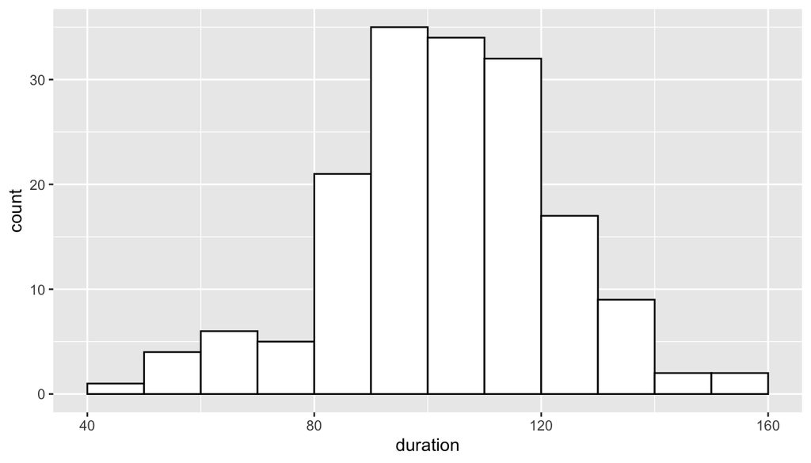

```r
ggplot(monona, aes(x=duration)) +
  geom_histogram(boundary = 0, binwidth = 10,
                 color = "black", fill = "white")
```

In approximately how many winters was the total duration where Lake Monona was at least 50% covered with ice between 40 to 70 days?

### Response

There are approximately 11 winters where Lake Monona was at least 50% covered with ice between 40 to 70 days.

#### 2.

Modify the code below so that:

- one of the bin boundaries is at 70 days
- the width of each bin is 5 days
- the fill color is “cyan”
- the color outlining the bars is “forestgreen”
- the x label says “Days Closed with Ice”
- the y label says “Total”
- there is a title with words of your choosing that describe the figure

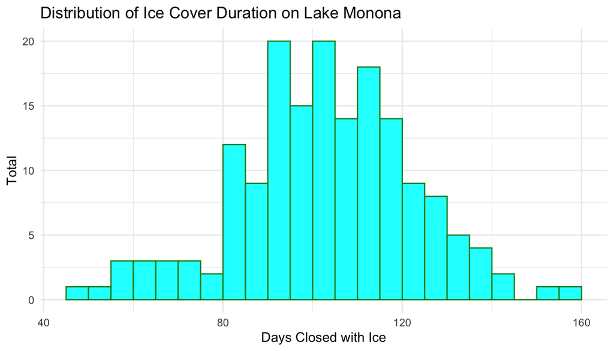

```r
ggplot(monona, aes(x = duration)) +
  geom_histogram(binwidth = 5, boundary=70, color = "forestgreen", fill = "cyan") +
  labs(x = "Days Closed with Ice", y = "Total", title = "Distribution of Ice Cover Duration on Lake Monona") + theme_minimal()
```

#### 3.

Code in the next chunk makes a scatter plot that shows how the variable `duration` changes with time (using `year1`).

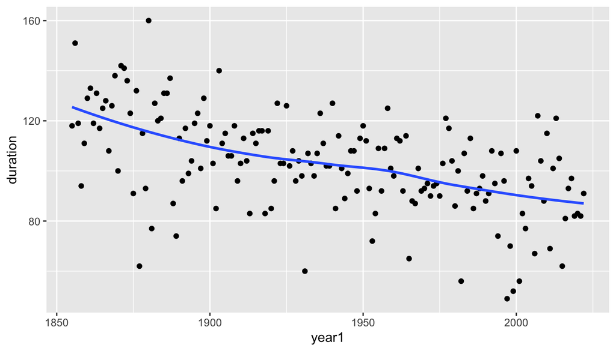

```r
ggplot(monona, aes(x = year1, y = duration)) +
  geom_point() +
  geom_smooth(se=FALSE)
```

- What does the line of code `geom_smooth(se=FALSE)` do? (Explain what it adds to the plot; you don’t need to explain details of the method.)

### Response

The geom_smooth(se=FALSE) line of code adds a smoothed trend line to the scatter plot, representing a generalized relationship between the two variables plotted on the x-axis (year1) and the y-axis (duration).

- Describe the pattern of the curve.

### Response

The pattern of the curve in the scatter plot appears to be decreasing over time, which suggests that as the years progress, the duration of ice cover (measured in days) on Lake Monona is generally declining. The curve seems to start higher in earlier years and gradually slopes downward towards more recent years.

- How long was Lake Monona closed with closed with ice in a typical year near 1875 (i.e., what is the approximate value of the smooth curve around 1875)?

### Response

Aproximately 118 days was how long Lake Monona was closed with closed with ice around 1875.

- How long was Lake Monona closed with ice in a typical year near 2000 (i.e., what is the approximate value of the smooth curve around 2000)?

### Response

Aproximately 90 days was how long Lake Monona was closed with closed with ice around 2000.

#### 4.

Modify the code in the following chunk so that:

- There is a box plot displaying the distribution of the days Lake Monona is closed by ice
- The box plot fill color is “yellow”
- The color of the edges of the box plot is “magenta”
- There is a more descriptive y-axis label
- There is an informative plot title

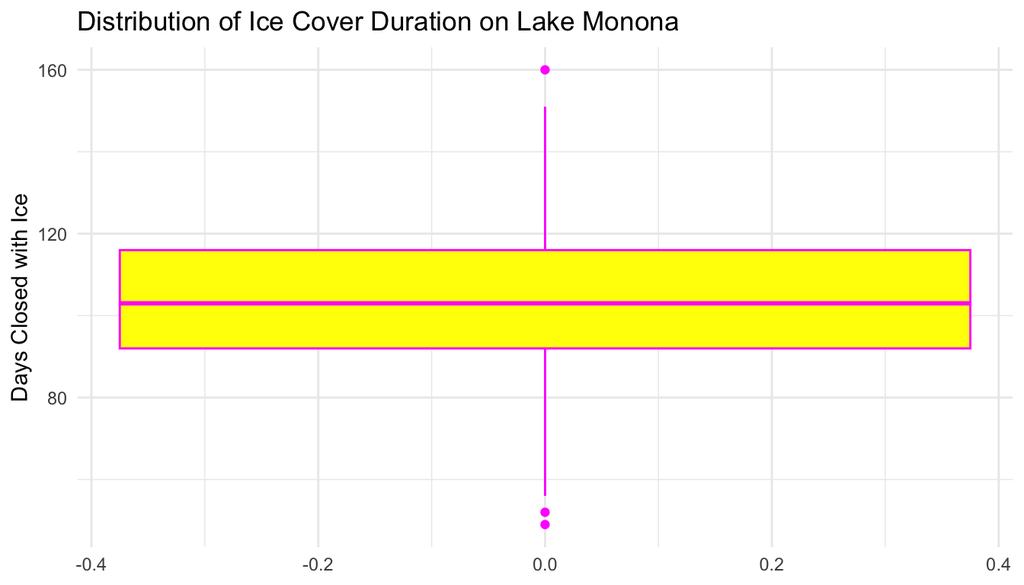

```r
ggplot(monona, aes(y = duration)) +
  geom_boxplot(color = "magenta", fill = "yellow") +
  labs(y = "Days Closed with Ice",
       title = "Distribution of Ice Cover Duration on Lake Monona") +
  theme_minimal()
```

- What is the approximate median number of days Lake Monona has been closed with ice?

### Response

105 days is the approximate median number of days Lake Monona has been closed with ice.

#### 5.

Write code to create a bar graph which displays the number of winters when the first freeze occured in each half-month period of time as recorded in the variable `ff_cat`. Choose your own colors if you do not like the default values. Make sure that your plot:

- has an informative title and subtitle
- has informative axis labels

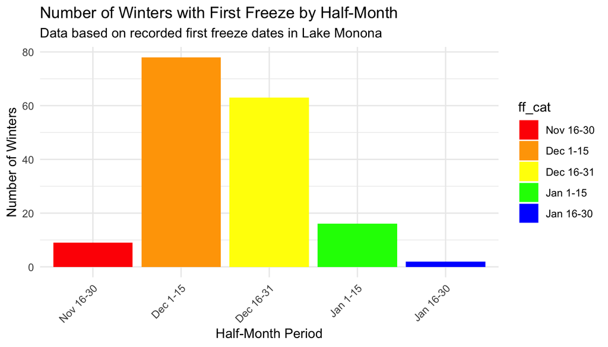

```r
ggplot(monona, aes(x = ff_cat, fill = ff_cat)) + geom_bar() +
  scale_fill_manual(values = c("red", "orange", "yellow", "green", "blue")) +
  labs(title = "Number of Winters with First Freeze by Half-Month",
       subtitle = "Data based on recorded first freeze dates in Lake Monona",
       x = "Half-Month Period",
       y = "Number of Winters") +
  theme_minimal() +
  theme(axis.text.x = element_text(angle = 45, hjust = 1))
```

#### 6.

Briefly explain why you needed to use the command `geom_bar()` and not `geom_col()` to make the plot in the previous problem.

You use geom_bar() instead of geom_col() because geom_bar() is designed for creating bar charts from data and automatically counts the occurrences for each category, which is exactly what you need for displaying the number of winters per half-month period. However, geom_col() expects already summarized data and displays the heights of the bars to represent values, making it less efficient where counting is required.

#### 7.

The following chunk creates a scatter plot with `ff_x` on the x axis and `duration` on the y axis, with points colored by `period50`. The variable `ff_x` is a numerical coding of the first freeze date, counting days after June 30. For context, December 27 is 180 days after June 30. The default color scheme is changed to `viridis` which is friendlier to most people with various forms of color blindness. The command `geom_smooth(method = "lm", se = FALSE)` adds a straight line instead of a curve to the plot (that’s the `method = "lm"` argument) and because we specified `period50` as a grouping variable by mapping it to the color aesthetic, separate lines are added for each group.

Add code to add a plot title and to provide informative axis labels. Following examples from lecture notes, change the title of the color legend to say “Time Period” instead of “period50”.

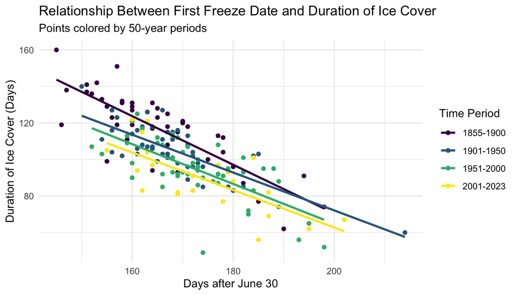

```r
ggplot(monona, aes(x = ff_x, y = duration, color = period50)) + geom_point() +
  geom_smooth(se = FALSE, method = "lm") +
  scale_color_viridis_d(name = "Time Period") +
  labs(x = "Days after June 30", y = "Duration of Ice Cover (Days)",
       title = "Relationship Between First Freeze Date and Duration of Ice Cover",
       subtitle = "Points colored by 50-year periods") +
  theme_minimal()
```

After making the graph, suppose that the date of the first freeze in some year was December 27, which is 180 days after June 30. Based on an examination of the graph, briefly explain how your prediction of the total duration that Lake Monona is closed by ice would differ if the winter was in the 1870s versus the present?

If the winter was in the 1870s, for a first freeze occurring on December 27, I predict a longer duration of ice cover. If the winter was in the present, the duration of ice cover in recent times tends to be shorter because the overall warmer winter temperatures mean ice cover doesn’t last as long. Therefore, for a recent winter, the prediction would be a shorter duration of ice cover following a first freeze on the same date.

#### 8.

The previous plot used color to distinguish which points were in each 50-year period of time. Write code to plot the same data in a scatter plot, but use a different facet (use `facet_wrap()`, following an example in the lecture notes) for each of the four different 50-year periods of time.

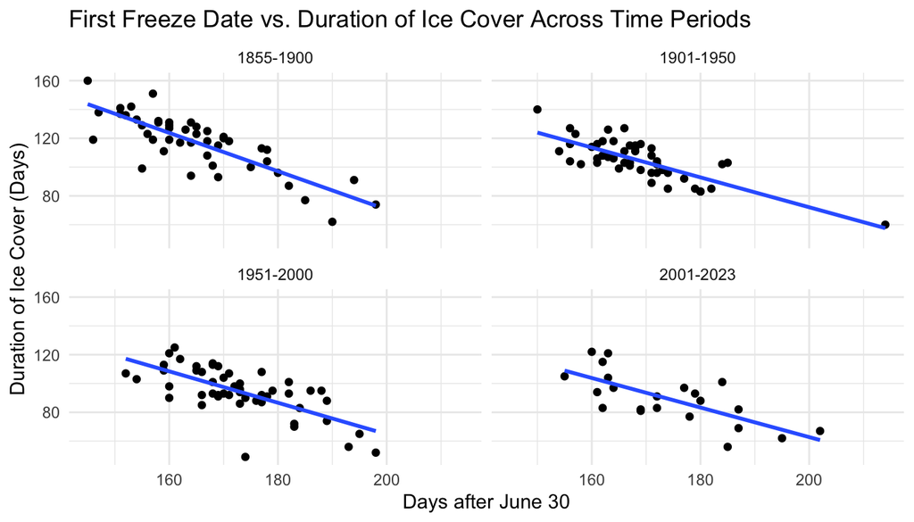

```r
ggplot(monona, aes(x = ff_x, y = duration)) +
  geom_point() + geom_smooth(se = FALSE, method = "lm") + facet_wrap(~period50) +
  labs(x = "Days after June 30", y = "Duration of Ice Cover (Days)",
       title = "First Freeze Date vs. Duration of Ice Cover Across Time Periods") +
  theme_minimal()
```

Does color or faceting make it easier to compare the relationship between first date of closing with ice and the total duration of the freeze among different 50-year time periods?

Faceting offers a clearer comparison of the relationship between first freeze dates and ice cover duration across different 50-year periods by organizing the data into separate panels for each period. This approach simplifies identifying trends and changes over time, avoiding the confusion that can arise from overlapping colors in a single plot. While color coding provides a unified view, it may obscure detailed comparisons due to color similarities and dense data points. Thus, faceting is more effective for analyzing and comparing data trends across time periods.